# Multinomial Logistic Regression Practical

### Regularization

The algorithm for logistic regression tries to minimize the *log-likelihood* function

$$\tag{1}
\mathcal{L}(\hat{y}, y) = y \log(\hat{y}) + (1-y) \log(1-\hat{y}) \\$$

through successive iterations, much like the Newton-Rhapson algorithm. We, ddd a penalty term to likelihood so we don’t overfit! By increasing the regularization parameter $\lambda$, we ‘increase’ the minimum cost.

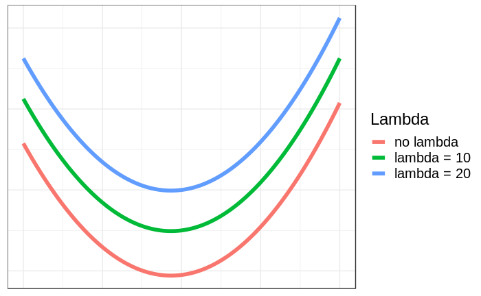

Let’s see what happens when we train a bunch of models with different lambda values!

```r
## What happens to the cost function with different values of lambda?
grid <- c(0.1, 1, 5, 10, 30, 50, 100)
result <- list()
for(value in grid) {

  ## Train model with lambda value
  mod <- mlogistic(iris_train[,1:4], iris_train[, 5], lambda = value)

  ## Retrieve costs
  costs <- lapply(mod$models, function(x) x$model_information$costs)

  ## Bind into a matrix
  costs_matrix <- do.call(cbind, costs)

  ## Calculate mean cost as an approximation
  avg_cost <- apply(costs_matrix, 1, mean)

  ## Save results to list
  result[[paste0("lambda", value)]] <- avg_cost

}

## Bind the columns together
result_bind <- do.call(cbind, result)
## Reshape the data from wide --> long format
library(reshape2)
result_bind_long <- melt(result_bind)
## Add iteration numbers
result_bind_long$iteration <- rep(1:2000, length(grid))

## Plot
library(ggplot2)
ggplot(result_bind_long, aes(x=iteration, y=value, color=Var2)) +
  geom_line() +
  theme_bw() +
  theme(legend.title = element_text("Lambda")) +
  scale_x_continuous(name = "Iteration") +
  scale_y_continuous(name = "Cost")
```

[output not shown]

**Q. The coefficients are assumed to be unbiased population parameters. Given the effect of the l2-regularization on the coefficients, can this still be the case? Think of the bias/variance trade-off and how you would test for this. Would confidence intervals help?**

We train a new model with a high lambda value and see if this creates a better fit on the data

```r
caret::confusionMatrix(as.factor(preds$class), iris_train[, 5])
```

```
Confusion Matrix and Statistics

            Reference
Prediction   setosa versicolor virginica
  setosa         36          3         0
  versicolor      0         34         9
  virginica       0          0        21

Overall Statistics

               Accuracy : 0.8835
                 95% CI : (0.8053, 0.9383)
    No Information Rate : 0.3592
    P-Value [Acc > NIR] : < 2.2e-16

                  Kappa : 0.823
 Mcnemar's Test P-Value : NA

Statistics by Class:

                     Class: setosa Class: versicolor Class: virginica
Sensitivity                 1.0000            0.9189           0.7000
Specificity                 0.9552            0.8636           1.0000
Pos Pred Value              0.9231            0.7907           1.0000
Neg Pred Value              1.0000            0.9500           0.8902
Prevalence                  0.3495            0.3592           0.2913
Detection Rate              0.3495            0.3301           0.2039
Detection Prevalence        0.3786            0.4175           0.2039
Balanced Accuracy           0.9776            0.8913           0.8500
```

Predict on the development set

```r
caret::confusionMatrix(as.factor(preds_dev$class), iris_dev[, 5])
```

```
Confusion Matrix and Statistics

            Reference
Prediction   setosa versicolor virginica
  setosa          5          0         0
  versicolor      0          6         1
  virginica       0          0         9

Overall Statistics

               Accuracy : 0.9524
                 95% CI : (0.7618, 0.9988)
    No Information Rate : 0.4762
    P-Value [Acc > NIR] : 4.125e-06

                  Kappa : 0.9261
 Mcnemar's Test P-Value : NA

Statistics by Class:

                     Class: setosa Class: versicolor Class: virginica
Sensitivity                 1.0000            1.0000           0.9000
Specificity                 1.0000            0.9333           1.0000
Pos Pred Value              1.0000            0.8571           1.0000
Neg Pred Value              1.0000            1.0000           0.9167
Prevalence                  0.2381            0.2857           0.4762
Detection Rate              0.2381            0.2857           0.4286
Detection Prevalence        0.2381            0.3333           0.4286
Balanced Accuracy           1.0000            0.9667           0.9500
```

**Q. Is this a better fit? Why/why not?**

```r
caret::confusionMatrix(as.factor(preds_test$class), iris_test[, 5])
```

```
Confusion Matrix and Statistics

            Reference
Prediction   setosa versicolor virginica
  setosa          9          0         0
  versicolor      0          6         4
  virginica       0          1         6

Overall Statistics

               Accuracy : 0.8077
                 95% CI : (0.6065, 0.9345)
    No Information Rate : 0.3846
    P-Value [Acc > NIR] : 1.298e-05

                  Kappa : 0.7143
 Mcnemar's Test P-Value : NA

Statistics by Class:

                     Class: setosa Class: versicolor Class: virginica
Sensitivity                 1.0000            0.8571           0.6000
Specificity                 1.0000            0.7895           0.9375
Pos Pred Value              1.0000            0.6000           0.8571
Neg Pred Value              1.0000            0.9375           0.7895
Prevalence                  0.3462            0.2692           0.3846
Detection Rate              0.3462            0.2308           0.2308
Detection Prevalence        0.3462            0.3846           0.2692
Balanced Accuracy           1.0000            0.8233           0.7688
```

**Q. What does this do to interpretability if the coefficients? What happened to them?**

```r
print(mclr3$models$setosa$model_information$params) # Model with lambda
```

```
$w
     Sepal.Length Sepal.Width Petal.Length Petal.Width
[1,]   -0.1378853  0.08264681   -0.4232964  -0.1757705

$b
[1] 1.523654
```

**Q. When do you think that regularization is a good technique? In what sort of situations would you use it?**